# Flint Water Crisis

Bob

1-14-2018

# Introduction

Here is a test code chunk. CONTROL + OPTION + I adds a code chunk on Mac. On Windows, it’s COMMAND + ALT + I.

```r
library(usethis)
use_git_config(user.name = "Bob Eisinger", user.email = "robert.eisinger@duke.edu")
```

The data set consists of 271 homes sampled with three water lead contaminant values at designated time points. The lead content is in parts per billion (ppb). Additionally, some location data is given about each home.

To get started, read in the `flint.csv` file using function `read_csv()`.

```r
library(tidyverse)
```

```r
flint <- read_csv("flint.csv")
```

Let’s preview the data with function `glimpse()`

```r
glimpse(flint)
```

```
Observations: 813
Variables: 5
$ id   <dbl> 1, 2, 4, 5, 6, 7, 8, 9, 12, 13, 15, 16, 17, 18, 19, 20, 21,…
$ zip  <dbl> 48504, 48507, 48504, 48507, 48505, 48507, 48507, 48503, 485…
$ ward <dbl> 6, 9, 1, 8, 3, 9, 9, 5, 9, 3, 9, 5, 2, 7, 9, 9, 5, 6, 2, 6,…
$ draw <chr> "first", "first", "first", "first", "first", "first", "firs…
$ lead <dbl> 0.344, 8.133, 1.111, 8.007, 1.951, 7.200, 40.630, 1.100, 10…
```

- **id**: sample id number
- **zip**: zip code in Flint as to the water sample’s location
- **ward**: ward in Flint as to the water sample’s location
- **draw**: water sample at one of three time points
- **lead**: lead content in parts per billion

# Analysis

## Summary data

#### Part I

Let’s see how many samples were taken from each zip code.

```r
flint %>%               # data
  group_by(zip) %>%     # perform a grouping by zip code
  count()               # count occurrences
```

| zip | n |
| --- | --- |
| 48502 | 3 |
| 48503 | 207 |
| 48504 | 165 |
| 48505 | 144 |
| 48506 | 132 |
| 48507 | 153 |
| 48529 | 3 |
| 48532 | 6 |

Which zip code had the most samples drawn?

#### Part II

Next, let’s look at the mean and median lead contaminant values for each zip code and draw combination. We have eight zip codes and samples taken at three time points. How many combinations do we have?

```r
flint %>%
  group_by(zip, draw) %>%
  summarise(mean_pb = mean(lead))
```

| zip | draw | mean_pb |
| --- | --- | --- |
| 48502 | first | 2.273000 |
| 48502 | second | 2.808000 |
| 48502 | third | 3.048000 |
| 48503 | first | 10.956435 |
| 48503 | second | 5.659130 |
| 48503 | third | 3.766203 |
| 48504 | first | 13.176127 |
| 48504 | second | 32.600273 |
| 48504 | third | 5.131473 |
| 48505 | first | 6.089333 |

[output cut: 14 more lines]

```r
flint %>%
  group_by(zip, draw) %>%
  summarise(median_pb = median(lead))
```

| zip | draw | median_pb |
| --- | --- | --- |
| 48502 | first | 2.2730 |
| 48502 | second | 2.8080 |
| 48502 | third | 3.0480 |
| 48503 | first | 5.1530 |
| 48503 | second | 2.4740 |
| 48503 | third | 1.2260 |
| 48504 | first | 2.8280 |
| 48504 | second | 1.2210 |
| 48504 | third | 0.7440 |
| 48505 | first | 3.3215 |

[output cut: 14 more lines]

How many rows are in each of two above data frames?

#### Part III

Modify the code below to compute the mean and median lead contaminant values for zip code 48503 at the first draw. What should you put in for `draw == "-----"`? Don’t forget to uncomment the second line of code.

```r
flint %>%
  filter(zip == 48503, draw == "first") %>%
  summarise(mean_pb = mean(lead),
            median_pb = median(lead),
            count_pb = n())
```

| mean_pb | median_pb | count_pb |
| --- | --- | --- |
| 10.95643 | 5.153 | 69 |

## Visualizations

Let’s make some plots, where we will focus on zip codes 48503, 48504, 48505, 48506, and 48507. We will restrict our attention to samples with lead values less than 1,000 ppb.

```r
flint_focus <- flint %>%
  filter(zip %in% 48503:48507, lead < 1000)
```

Below are side-by-side box plots for the three flushing times in each of the five zip codes considered. Add `x` and `y` labels; add a title by inserting `title = "title_name"` inside the `labs()` function.

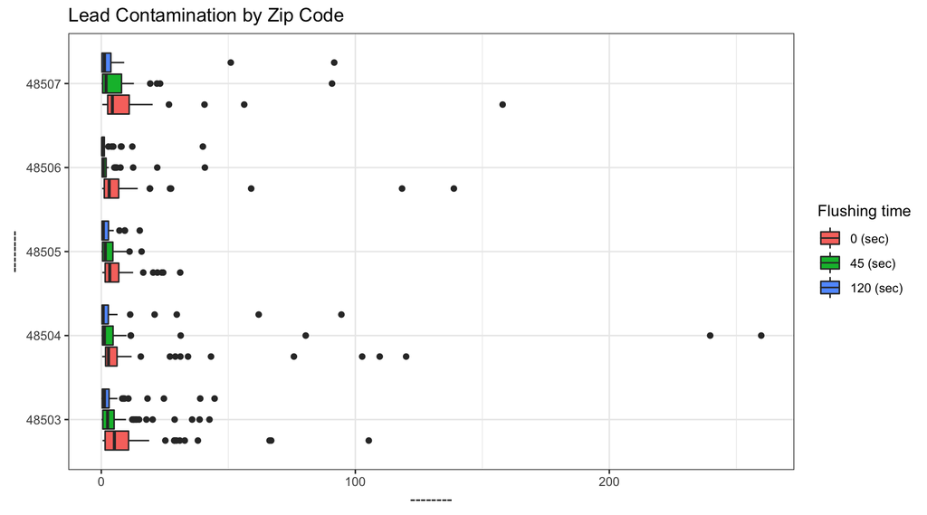

```r
ggplot(data = flint_focus, aes(x = factor(zip), y = lead)) +
  geom_boxplot(aes(fill = factor(draw))) +
  labs(x = "--------", y = "--------", fill = "Flushing time",
       title = "Lead Contamination by Zip Code") +
  scale_fill_discrete(breaks = c("first", "second", "third"),
                      labels = c("0 (sec)", "45 (sec)", "120 (sec)")) +
  coord_flip() +
  theme_bw()
```

Add labels for `x`, `y`, a `title`, and `subtitle` to the code below to update the corresponding plot.

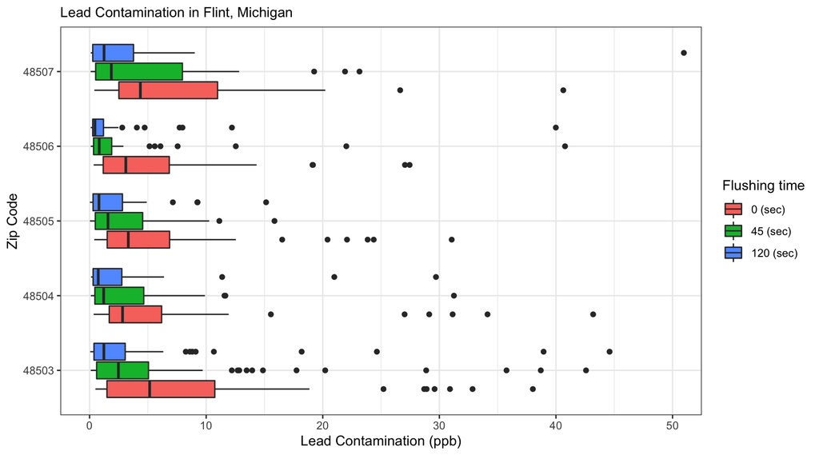

```r
ggplot(data = flint_focus, aes(x = factor(zip), y = lead)) +
  geom_boxplot(aes(fill = factor(draw))) +
  labs(x = "Zip Code", y = "Lead Contamination (ppb)", fill = "Flushing time",
       subtitle = "Lead Contamination in Flint, Michigan") +
  scale_fill_discrete(breaks = c("first", "second", "third"),
                      labels = c("0 (sec)", "45 (sec)", "120 (sec)")) +
  coord_flip(ylim = c(0, 50)) +
  theme_bw()
```

What is the difference between the two plots?

# References

1. Langkjaer-Bain, R. (2017), The murky tale of Flint’s deceptive water data. Significance, 14: 16-21.